# Pertemuan 2

Natasha Muti Hafiza

2023-09-05

```r
library(dplyr)
library(TTR)
library(forecast)
library(lmtest)
library(orcutt)
library(HoRM)
```

```r
library(scales)
library(ggplot2)
library(corrplot)
data_wine <- rio::import("https://raw.githubusercontent.com/natashamuti/mpdw-ako/main/pertemuan%202/data_wine.csv")
data_wine
```

```
##    Year Harvested Production   Price
## 1  2020       579       1770 1325.99
## 2  2019       711       3200 1419.69
## 3  2018       711       2280 1486.84
## 4  2017       683       2010 1479.10
## 5  2016       696       2010 1375.62
## 6  2015       900       1710 1300.00
## 7  2014       900       1960 1391.33
## 8  2013       910       2460 1388.21
## 9  2012       910       2275 1236.92
## 10 2011       900       2160 1350.00
## 11 2010       800       2400 1300.00
## 12 2009       800       2800 1200.00
## 13 2008       600       1170 1100.00
## 14 2007       650       1625 1100.31
```

[output cut: 26 more lines]

## Eksplorasi Data

```r
summary(data_wine)
```

```
##       Year        Harvested       Production         Price
##  Min.   :1980   Min.   : 50.0   Min.   :  40.0   Min.   : 340.0
##  1st Qu.:1991   1st Qu.:210.0   1st Qu.: 517.5   1st Qu.: 557.5
##  Median :2000   Median :470.0   Median :1220.0   Median :1005.0
##  Mean   :2000   Mean   :443.2   Mean   :1237.1   Mean   : 934.0
##  3rd Qu.:2010   3rd Qu.:686.2   3rd Qu.:1817.5   3rd Qu.:1252.7
##  Max.   :2020   Max.   :910.0   Max.   :3200.0   Max.   :1486.8
```

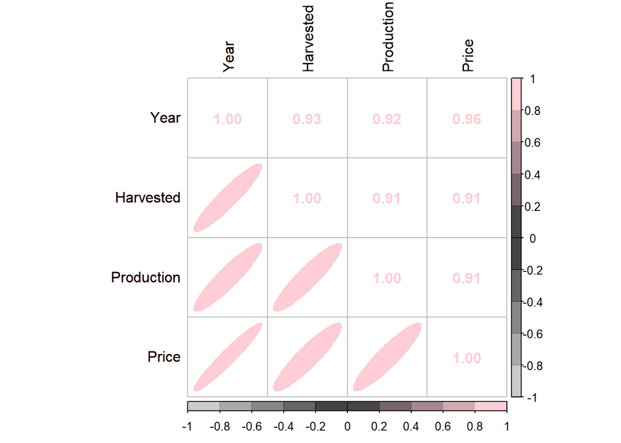

```r
#Membuat matriks korelasi
wain <- cor(data_wine)

colors <- alpha(colorRampPalette(c("grey", #Warna Bawah
                                   "black", #Warna Tengah
                                   "pink"))(10), #Warna Atas
                                   alpha = 0.80) #Transparan

corrplot(wain, method = 'ellipse', type='lower', order='original', col=colors)
corrplot(wain, add=TRUE, method = 'number', type='upper', order='original',
         tl.pos = "lt",
         tl.col = "black", col=colors)
```

```r
#Membentuk objek time series
data.ts<-ts(data_wine$Price)
data.ts
```

```
## Time Series:
## Start = 1
## End = 40
## Frequency = 1
##  [1] 1325.99 1419.69 1486.84 1479.10 1375.62 1300.00 1391.33 1388.21 1236.92
## [10] 1350.00 1300.00 1200.00 1100.00 1100.31 1062.18 1200.00 1050.00 1000.00
## [19]  971.00 1200.00 1000.00 1140.00  900.00 1010.00  945.00  560.00  600.00
## [28]  580.00  612.00  525.00  550.00  629.00  521.00  400.00  340.00  420.00
## [37]  400.00  400.00  450.00  440.00
```

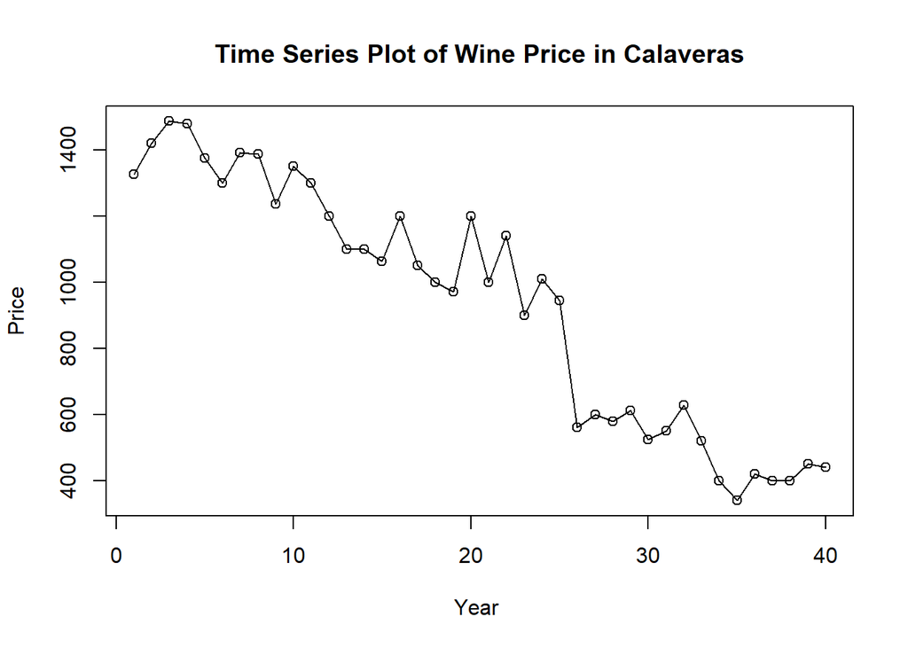

```r
#Membuat plot time series
ts.plot(data.ts, xlab="Year ", ylab="Price", main= "Time Series Plot of Wine Price in Calaveras")
points(data.ts)
```

## Regresi

```r
#Pembuatan Model Regresi
#model regresi
model<- lm(Price~Year+Harvested+Production, data = data_wine)
summary(model)
```

```
##
## Call:
## lm(formula = Price ~ Year + Harvested + Production, data = data_wine)
##
## Residuals:
##      Min       1Q   Median       3Q      Max
## -204.715  -63.423   -7.365   51.568  246.095
##
## Coefficients:
##               Estimate Std. Error t value Pr(>|t|)
## (Intercept) -4.516e+04  8.730e+03  -5.173 8.85e-06 ***
## Year         2.297e+01  4.403e+00   5.218 7.71e-06 ***
## Harvested    6.055e-02  1.807e-01   0.335    0.739
## Production   9.201e-02  5.675e-02   1.621    0.114
## ---
## Signif. codes:  0 '***' 0.001 '**' 0.01 '*' 0.05 '.' 0.1 ' ' 1
##
## Residual standard error: 107.9 on 36 degrees of freedom
## Multiple R-squared:  0.9238, Adjusted R-squared:  0.9175
## F-statistic: 145.6 on 3 and 36 DF,  p-value: < 2.2e-16
```

Model yang dihasilkan adalah
$$y_i=-4.516*10^4+22.97x_t+0.06055x_(t-1)+0.09201x_(t-2)$$
Berdasarkan ringkasan model dapat diketahui bahwa hasil uji F memiliki *p-value* < $\alpha$ (5%). Artinya, minimal terdapat satu variabel yang berpengaruh nyata terhadap model.

Selanjutnya dapat dilihat juga nilai $R^2=0.9238$. Artinya, sebesar 92.38% keragaman harga wine dapat dijelaskan oleh peubah tahun panen, dan produksi. Hasil ini menunjukkan hasil yang bagus, seolah mendapatkan hasil terbaik. Namun, kita perlu melakukan uji terhadap sisaannya seperti berikut ini.

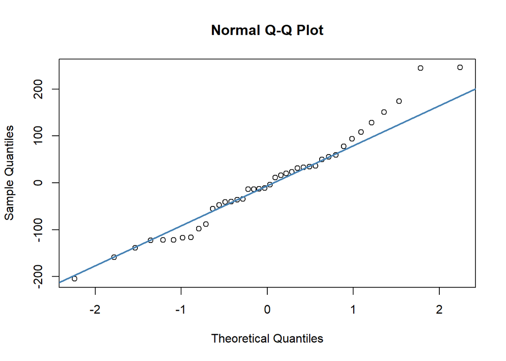

```r
#sisaan dan fitted value
sisaan<- residuals(model)
fitValue<- predict(model)

#Diagnostik dengan eksploratif
par(mfrow = c(1,1))
qqnorm(sisaan)
qqline(sisaan, col = "steelblue", lwd = 2)
```

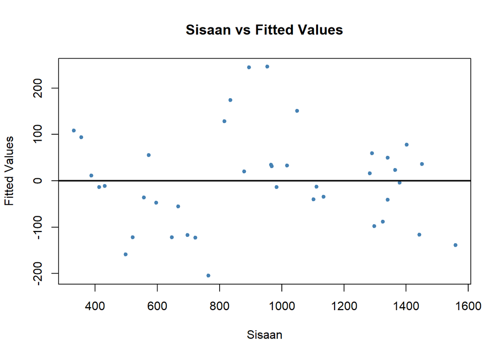

```r
plot(fitValue, sisaan, col = "steelblue", pch = 20, xlab = "Sisaan", ylab = "Fitted Values", main = "Sisaan vs Fitted Values")
abline(a = 0, b = 0, lwd = 2)
```

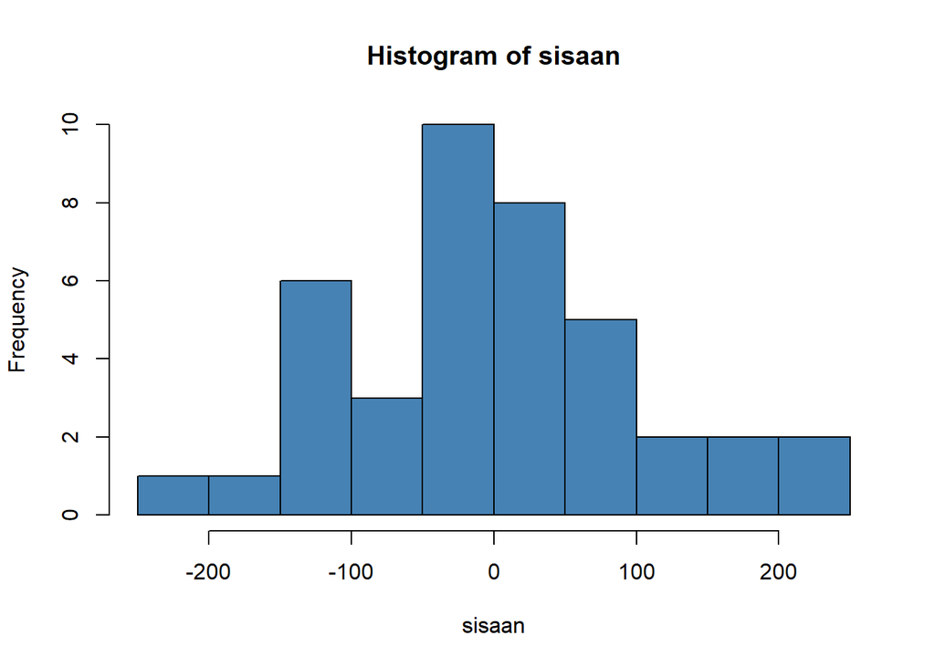

```r
hist(sisaan, col = "steelblue")
```

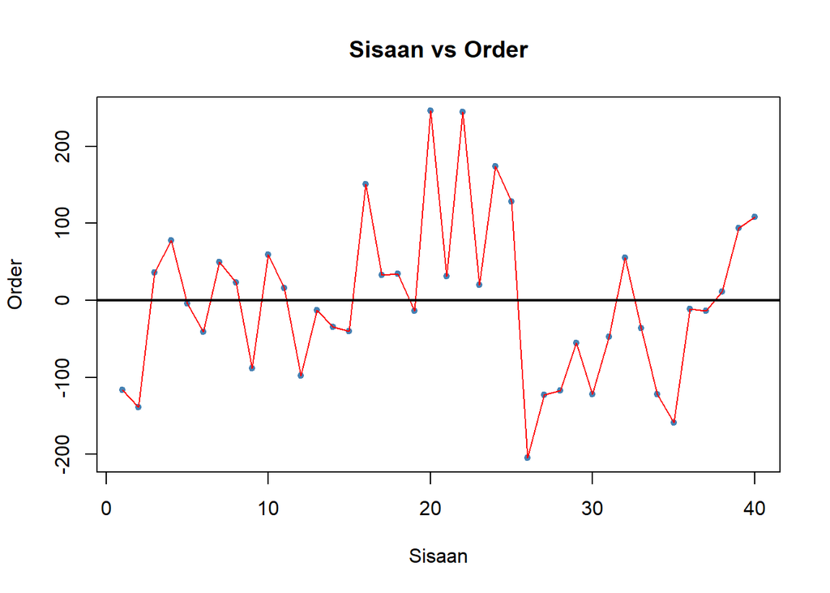

```r
plot(seq(1,40,1), sisaan, col = "steelblue", pch = 20, xlab = "Sisaan", ylab = "Order", main = "Sisaan vs Order")
lines(seq(1,40,1), sisaan, col = "red")
abline(a = 0, b = 0, lwd = 2)
```

Normal Q-Q Plot menunjukkan bahwa sisaan cenderung menyebar normal. Namun, histogram tidak menunjukkan demikian. Plot antara sisaan vs order menunjukkan adanya autokorelasi karena ada pola antar sisaan.

```r
#Melihat Sisaan Menyebar Normal/Tidak
#H0: sisaan mengikuti sebaran normal
#H1: sisaan tidak mengikuti sebaran normal
shapiro.test(sisaan)
```

```
##
##  Shapiro-Wilk normality test
##
## data:  sisaan
## W = 0.97326, p-value = 0.4535
```

```r
ks.test(sisaan, "pnorm", mean=mean(sisaan), sd=sd(sisaan))
```

```
##
##  Exact one-sample Kolmogorov-Smirnov test
##
## data:  sisaan
## D = 0.089853, p-value = 0.8747
## alternative hypothesis: two-sided
```

Berdasarkan uji formal Saphiro-Wilk dan Kolmogorov-Smirnov didapatkan nilai *p-value* > $\alpha$ (5%). Artinya, cukup bukti untuk menyatakan sisaan berdistribusi normal.

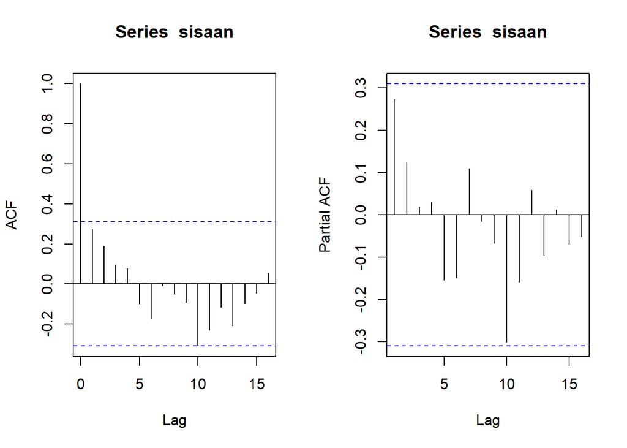

```r
#ACF dan PACF identifikasi autokorelasi
par(mfrow = c(1,2))
acf(sisaan)
pacf(sisaan)
```

```r
#Deteksi autokorelasi dengan uji-Durbin Watson
#H0: tidak ada autokorelasi
#H1: ada autokorelasi
dwtest(model)
```

```
##
##  Durbin-Watson test
##
## data:  model
## DW = 1.3922, p-value = 0.009369
## alternative hypothesis: true autocorrelation is greater than 0
```

## Penanganan Autokorelasi

### Metode Cochrane-Orcutt

```r
#Penanganan Autokorelasi Cochrane-Orcutt
modelCO<-cochrane.orcutt(model)
modelCO
```

```
## Cochrane-orcutt estimation for first order autocorrelation
##
## Call:
## lm(formula = Price ~ Year + Harvested + Production, data = data_wine)
##
##  number of interaction: 13
##  rho 0.404054
##
## Durbin-Watson statistic
## (original):    1.39219 , p-value: 9.369e-03
## (transformed): 2.12577 , p-value: 5.488e-01
##
##  coefficients:
##   (Intercept)          Year     Harvested    Production
## -66874.077351     33.930632     -0.217178      0.035850
```

Hasil keluaran model setelah dilakukan penanganan adalah sebagai berikut.
$$y_i=-66874.077351+33.930632x_t+-0.217178x_(t-1)+0.035850x_(t-2)$$
Hasil juga menunjukkan bahwa nilai DW dan p-value meningkat menjadi $2.12577$ dan $0.5488$. Nilai DW sudah berada pada rentang DU < DW < 4-DU atau $1.6589 < DW < 2.3411$. Hal tersebut juga didukung dengan nilai *p-value* > 0.05, artinya belum cukup bukti menyatakan bahwa sisaan terdapat autokorelasi pada taraf nyata 5%. Untuk nilai $ρ ̂$ optimum yang digunakan adalah $0.4040536$. Nilai tersebut dapat diketahui dengan *syntax* berikut.

```r
#Rho optimum
rho<- modelCO$rho
rho
```

```
## [1] 0.4040536
```

Selanjutnya akan dilakukan transformasi secara manual dengan syntax berikut ini.

```r
#Transformasi Manual
price.trans<- data_wine$Price[-1]-data_wine$Price[-40]*rho
year.trans<- data_wine$Year[-1]-data_wine$Year[-40]*rho
harvested.trans<- data_wine$Harvested[-1]-data_wine$Harvested[-40]*rho
production.trans<- data_wine$Production[-1]-data_wine$Production[-40]*rho

modelCOmanual<- lm(price.trans~year.trans+harvested.trans+production.trans)
summary(modelCOmanual)
```

```
##
## Call:
## lm(formula = price.trans ~ year.trans + harvested.trans + production.trans)
##
## Residuals:
##     Min      1Q  Median      3Q     Max
## -275.56  -58.55  -14.03   51.08  247.49
##
## Coefficients:
##                    Estimate Std. Error t value Pr(>|t|)
## (Intercept)      -3.985e+04  7.776e+03  -5.125 1.10e-05 ***
## year.trans        3.393e+01  6.578e+00   5.158 9.94e-06 ***
## harvested.trans  -2.172e-01  2.692e-01  -0.807    0.425
## production.trans  3.585e-02  5.171e-02   0.693    0.493
## ---
## Signif. codes:  0 '***' 0.001 '**' 0.01 '*' 0.05 '.' 0.1 ' ' 1
##
## Residual standard error: 99.14 on 35 degrees of freedom
## Multiple R-squared:  0.8383, Adjusted R-squared:  0.8245
## F-statistic:  60.5 on 3 and 35 DF,  p-value: 6.278e-14
```

```r
#Mencari Penduga Koefisien Regresi setelah Transformasi ke Persamaan Awal
b0bintang <- modelCOmanual$coefficients[-c(2,3,4)]
b0 <- b0bintang/(1-rho)
b1 <- modelCOmanual$coefficients[-c(1,3,4)]
b2 <- modelCOmanual$coefficients[-c(1,2,4)]
b3 <- modelCOmanual$coefficients[-c(1,2,3)]
b0
```

```
## (Intercept)
##   -66874.08
```

```r
b1
```

```
## year.trans
##   33.93063
```

```r
b2
```

```
## harvested.trans
##      -0.2171778
```

```r
b3
```

```
## production.trans
##       0.03585018
```

Hasil perhitungan koefisien regresi tersebut akan menghasilkan hasil yang sama dengan model yang dihasilkan menggunakan *packages*.

### Metode Hildreth-Lu

```r
#Penanganan Autokorelasi Hildreth lu
# Hildreth-Lu
hildreth.lu.func<- function(r, model){
  x1 <- model.matrix(model)[,2]
  x2 <- model.matrix(model)[,3]
  x3 <- model.matrix(model)[,4]

  y <- model.response(model.frame(model))
  n <- length(y)
  t <- 2:n

  y <- y[t]-r*y[t-1]
  x1 <- x1[t]-r*x1[t-1]
  x2 <- x2[t]-r*x2[t-1]
  x3 <- x3[t]-r*x3[t-1]

  return(lm(y~x1+x2+x3))
}

#Pencariab rho yang meminimumkan SSE
r <- c(seq(0.1,0.9, by= 0.1))
tab <- data.frame("rho" = r, "SSE" = sapply(r, function(i){deviance(hildreth.lu.func(i, model))}))
round(tab, 4)
```

```
##   rho      SSE
## 1 0.1 375540.6
## 2 0.2 358494.0
## 3 0.3 347855.8
## 4 0.4 344002.1
## 5 0.5 347484.0
## 6 0.6 359141.4
## 7 0.7 380157.8
## 8 0.8 411722.1
## 9 0.9 454415.5
```

Pertama-tama akan dicari di mana kira-kira $ρ$ yang menghasilkan SSE minimum. Pada hasil di atas terlihat $ρ$ minimum ketika 0.4. Namun, hasil tersebut masih kurang teliti sehingga akan dicari kembali $ρ$ yang lebih optimum dengan ketelitian yang lebih. Jika sebelumnya jarak antar $ρ$ yang dicari adalah 0.1, kali ini jarak antar $ρ$ adalah 0.001 dan dilakukan pada selang 0.2 sampai dengan 0.5.

```r
#Rho optimal di sekitar 0.4
rOpt <- seq(0.2,0.5, by= 0.001)
tabOpt <- data.frame("rho" = rOpt, "SSE" = sapply(rOpt, function(i){deviance(hildreth.lu.func(i, model))}))
head(tabOpt[order(tabOpt$SSE),])
```

```
##       rho      SSE
## 205 0.404 343996.1
## 206 0.405 343996.4
## 204 0.403 343996.5
## 207 0.406 343997.5
## 203 0.402 343997.6
## 208 0.407 343999.2
```

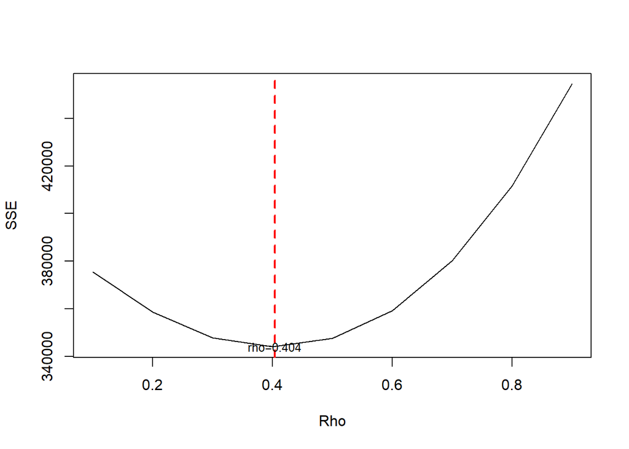

```r
#Grafik SSE optimum
par(mfrow = c(1,1))
plot(tab$SSE ~ tab$rho , type = "l", xlab = "Rho", ylab = "SSE")
abline(v = tabOpt[tabOpt$SSE==min(tabOpt$SSE),"rho"], lty = 2, col="red",lwd=2)
text(x=0.404, y=343996.1, labels = "rho=0.404", cex = 0.8)
```

Perhitungan yang dilakukan aplikasi `R` menunjukkan bahwa nilai $ρ$ optimum, yaitu saat SSE terkecil terdapat pada nilai $ρ=0.404$. Hal tersebut juga ditunjukkan pada plot. Selanjutnya, model dapat didapatkan dengan mengevaluasi nilai $ρ$ ke dalam fungsi `hildreth.lu.func`, serta dilanjutkan dengan pengujian autokorelasi dengan uji Durbin-Watson. Namun, setelah pengecekan tersebut tidak lupa koefisien regresi tersebut digunakan untuk transformasi balik. Persamaan hasil transformasi itulah yang menjadi persamaan sesungguhnya.

```r
#Model terbaik
modelHL <- hildreth.lu.func(0.404, model)
summary(modelHL)
```

```
##
## Call:
## lm(formula = y ~ x1 + x2 + x3)
##
## Residuals:
##     Min      1Q  Median      3Q     Max
## -275.55  -58.56  -14.03   51.08  247.48
##
## Coefficients:
##               Estimate Std. Error t value Pr(>|t|)
## (Intercept) -3.986e+04  7.776e+03  -5.126 1.10e-05 ***
## x1           3.393e+01  6.578e+00   5.158 9.94e-06 ***
## x2          -2.171e-01  2.692e-01  -0.807    0.425
## x3           3.585e-02  5.171e-02   0.693    0.493
## ---
## Signif. codes:  0 '***' 0.001 '**' 0.01 '*' 0.05 '.' 0.1 ' ' 1
##
## Residual standard error: 99.14 on 35 degrees of freedom
## Multiple R-squared:  0.8384, Adjusted R-squared:  0.8245
## F-statistic: 60.51 on 3 and 35 DF,  p-value: 6.262e-14
```

```r
#Transformasi Balik
cat("y = ", coef(modelHL)[1]/(1-0.404), "+", coef(modelHL)[2],"x1","+", coef(modelHL)[3],"x2","+", coef(modelHL)[4],"x3", sep = "")
```

```
## y = -66871.91+33.92954x1+-0.21714x2+0.03585216x3
```

```r
#Deteksi autokorelasi
dwtest(modelHL)
```

```
##
##  Durbin-Watson test
##
## data:  modelHL
## DW = 2.1257, p-value = 0.5486
## alternative hypothesis: true autocorrelation is greater than 0
```

Hasil uji Durbin-Watson juga menunjukkan bawah nilai DW sebesar $2.1257$ berada pada selang daerah tidak ada autokorelasi, yaitu pada rentang DU < DW < 4-DU atau $1.6589 < DW < 2.3411$. Hal tersebut juga didukung oleh *p-value* sebesar $0.5486$, di mana *p-value* > $\alpha$=5%. Artinya tak tolak $H_0$ atau belum cukup bukti menyatakan bahwa ada autokorelasi dalam data harga wine dengan metode Hildreth-Lu pada taraf nyata 5%.

Terakhir, akan dibandingkan nilai SSE dari ketiga metode (metode awal, metode Cochrane-Orcutt, dan Hildreth-Lu).

```r
#Perbandingan
sseModelawal <- anova(model)$`Sum Sq`[-c(1,2,3)]
sseModelCO <- anova(modelCOmanual)$`Sum Sq`[-c(1,2,3)]
sseModelHL <- anova(modelHL)$`Sum Sq`[-c(1,2,3)]
mseModelawal <- sseModelawal/length(data_wine$Price)
mseModelCO <- sseModelCO/length(data_wine$Price)
mseModelHL <- sseModelHL/length(data_wine$Price)
akurasi <- matrix(c(sseModelawal,sseModelCO,sseModelHL,
                    mseModelawal,mseModelCO,mseModelHL),nrow=2,ncol=3,byrow = T)
colnames(akurasi) <- c("Model Awal", "Model Cochrane-Orcutt", "Model Hildreth-Lu")
row.names(akurasi) <- c("SSE","MSE")
akurasi
```

```
##     Model Awal Model Cochrane-Orcutt Model Hildreth-Lu
## SSE  418996.31            343996.060        343996.061
## MSE   10474.91              8599.902          8599.902
```

Berdasarkan hasil tersebut dapat diketahui bahwa hasil penanganan autokorelasi dengan metode Cochrane-Orcutt dan Hildreth-Lu memiliki SSE yang sama, sebesar $343996.060$ dan lebih baik dibandingkan model awal ketika autokorelasi masih terjadi, yaitu sebesar $418996.31$.

# Simpulan

Autokorelasi yang terdapat pada dataset wine di Calaveras, california tahun 1980-2020 terjadi akibat adanya korelasi di antara unsur penyusunnya. Adanya autokorelasi menyebabkan model regresi kurang baik karena akan meingkatkan galatnya. Autokorelasi dapat dideteksi secara eksploratif melalui plot sisaan, ACF, dan PACF, serta dengan uji formal Durbin-Watson. Namun, autokorelasi tersebut dapat ditangani dengan metode Cochrane-Orcutt dan Hildreth-Lu. Kedua metode menghasilkan nilai SSE yang sama, artinya keduanya baik untuk digunakan.